# Homework 5

Ferhat Turhan

16 02 2021

## Introduction

In this homework, it is expected to forecast if an applicant will be a good salesperson or not based on his/her following attributes:

APT: Selling aptitude test score AGE: Age (in years) ANX: Anxiety test score EXP: Experience (in years) GPA: High school GPA

Relevant data is given, which can be found [here](https://bu-ie-360.github.io/fall20-ferhatturhan/files/sales.txt). The head of the data:

```
##   SALES APT  AGE ANX EXP GPA
## 1    44  10 22.1 4.9   0 2.4
## 2    47  19 22.4 3.0   1 2.6
## 3    60  27 23.1 1.5   0 2.8
## 4    71  31 24.0 0.6   3 2.7
## 5    61  64 22.6 1.8   2 2.0
## 6    60  81 21.6 3.3   1 2.5
```

In this homework it is expected to implement a stepwise regreession approach, and based on the final model, perform a test if GPA is an effective variable on explaining sales value. “Stepwise regression is the step-by-step iterative construction of a regression model that involves the selection of independent variables to be used in a final model. It involves adding or removing potential explanatory variables in succession and testing for statistical significance after each iteration.”

Let’s start analyzing with correlation coefficients and scatter plots between variables.

## Analysis

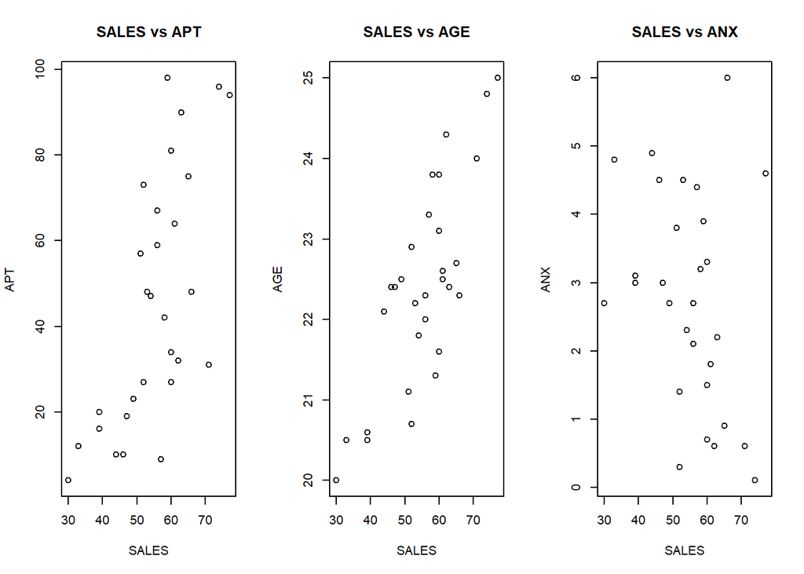

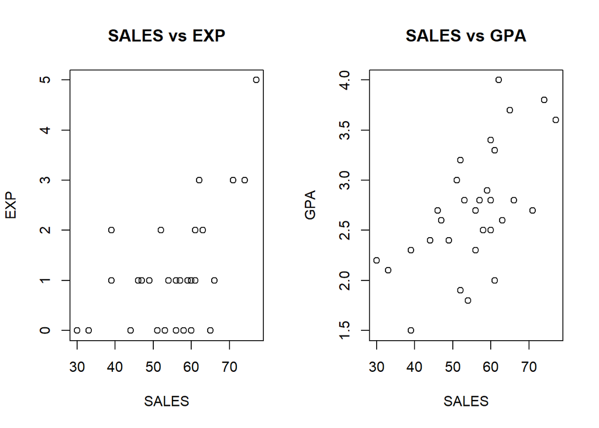

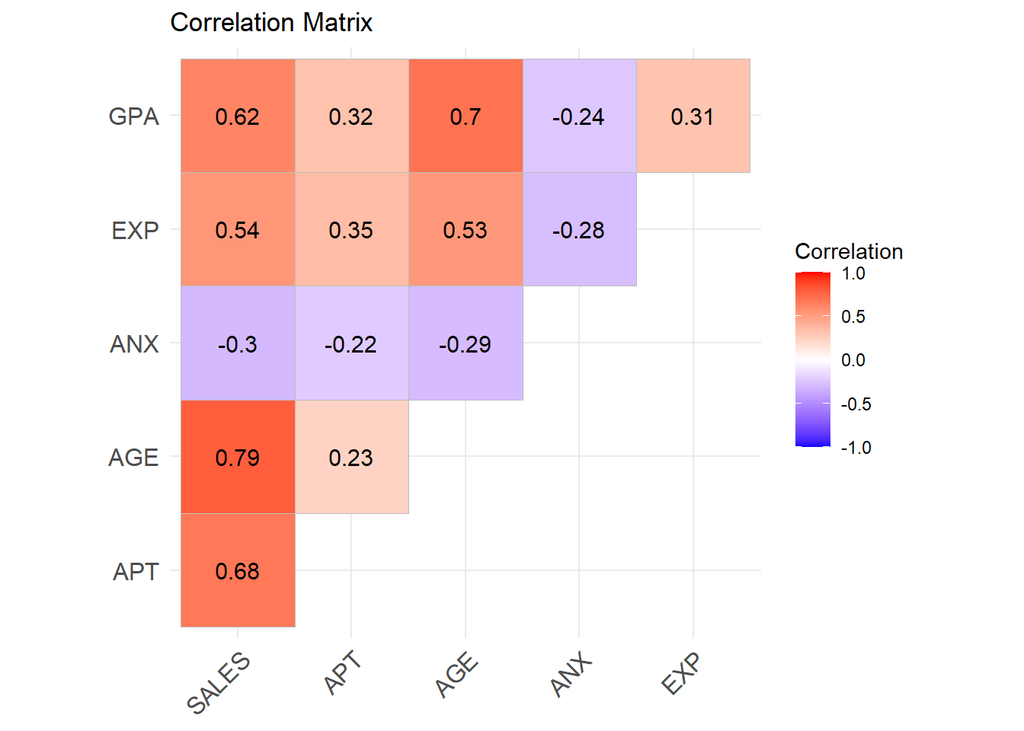

From coefficients above, it is meaningful to start the very first model using AGE, since this variable has the higher correlation with Sales.

```
##
## Call:
## lm(formula = SALES ~ AGE, data = data)
##
## Residuals:
##     Min      1Q  Median      3Q     Max
## -9.2810 -6.6102  0.6617  4.7184 11.4048
##
## Coefficients:
##             Estimate Std. Error t value Pr(>|t|)
## (Intercept)  -98.335     22.428  -4.385 0.000149 ***
## AGE            6.858      1.000   6.855  1.9e-07 ***
## ---
## Signif. codes:  0 '***' 0.001 '**' 0.01 '*' 0.05 '.' 0.1 ' ' 1
##
## Residual standard error: 6.904 on 28 degrees of freedom
## Multiple R-squared:  0.6266, Adjusted R-squared:  0.6133
## F-statistic: 46.99 on 1 and 28 DF,  p-value: 1.896e-07
```

Now, all of the other variables will be added one by one into the model and selected the best one among them.

```
##
## Call:
## lm(formula = SALES ~ AGE + APT, data = data)
##
## Residuals:
##    Min     1Q Median     3Q    Max
## -5.271 -2.275 -1.065  1.415 10.893
##
## Coefficients:
##             Estimate Std. Error t value Pr(>|t|)
## (Intercept) -83.8357    12.4356  -6.742 3.08e-07 ***
## AGE           5.7969     0.5643  10.273 7.94e-11 ***
## APT           0.2015     0.0248   8.124 1.00e-08 ***
## ---
## Signif. codes:  0 '***' 0.001 '**' 0.01 '*' 0.05 '.' 0.1 ' ' 1
##
## Residual standard error: 3.788 on 27 degrees of freedom
## Multiple R-squared:  0.8916, Adjusted R-squared:  0.8836
## F-statistic:   111 on 2 and 27 DF,  p-value: 9.404e-14
```

```
##
## Call:
## lm(formula = SALES ~ AGE + ANX, data = data)
##
## Residuals:
##     Min      1Q  Median      3Q     Max
## -9.3196 -6.7898  0.6643  4.8837 13.3007
##
## Coefficients:
##             Estimate Std. Error t value Pr(>|t|)
## (Intercept) -92.1563    24.4437  -3.770  0.00081 ***
## AGE           6.6524     1.0556   6.302 9.58e-07 ***
## ANX          -0.5821     0.8656  -0.672  0.50703
## ---
## Signif. codes:  0 '***' 0.001 '**' 0.01 '*' 0.05 '.' 0.1 ' ' 1
##
## Residual standard error: 6.972 on 27 degrees of freedom
## Multiple R-squared:  0.6328, Adjusted R-squared:  0.6056
## F-statistic: 23.26 on 2 and 27 DF,  p-value: 1.338e-06
```

```
##
## Call:
## lm(formula = SALES ~ AGE + EXP, data = data)
##
## Residuals:
##    Min     1Q Median     3Q    Max
## -8.947 -6.421  1.078  5.356 11.660
##
## Coefficients:
##             Estimate Std. Error t value Pr(>|t|)
## (Intercept)  -82.544     25.438  -3.245  0.00313 **
## AGE            6.066      1.170   5.186 1.85e-05 ***
## EXP            1.604      1.264   1.269  0.21523
## ---
## Signif. codes:  0 '***' 0.001 '**' 0.01 '*' 0.05 '.' 0.1 ' ' 1
##
## Residual standard error: 6.83 on 27 degrees of freedom
## Multiple R-squared:  0.6476, Adjusted R-squared:  0.6215
## F-statistic: 24.81 on 2 and 27 DF,  p-value: 7.66e-07
```

```
##
## Call:
## lm(formula = SALES ~ AGE + GPA, data = data)
##
## Residuals:
##     Min      1Q  Median      3Q     Max
## -9.4447 -5.9853  0.8064  5.3731 11.1424
##
## Coefficients:
##             Estimate Std. Error t value Pr(>|t|)
## (Intercept)  -87.846     26.670  -3.294 0.002764 **
## AGE            6.119      1.418   4.316 0.000191 ***
## GPA            2.232      3.010   0.742 0.464753
## ---
## Signif. codes:  0 '***' 0.001 '**' 0.01 '*' 0.05 '.' 0.1 ' ' 1
##
## Residual standard error: 6.96 on 27 degrees of freedom
## Multiple R-squared:  0.6341, Adjusted R-squared:  0.607
## F-statistic: 23.39 on 2 and 27 DF,  p-value: 1.276e-06
```

From the summaries of the potential variables that could be added, it can be said that residual standard error drops almost by half in model a, which corresponds to adding the variable APT. I can say that APT should be added since other possible models don’t seem to suggest a better model in terms of both residual standard error and adjusted R-squared values. Plus, they don’t seem to be statistically significant variables. Before moving on, let’s see ANOVA tables of all of the possible new models.

```
## Analysis of Variance Table
##
## Model 1: SALES ~ AGE
## Model 2: SALES ~ AGE + APT
##   Res.Df     RSS Df Sum of Sq      F Pr(>F)
## 1     28 1334.50
## 2     27  387.47  1    947.03 65.992  1e-08 ***
## ---
## Signif. codes:  0 '***' 0.001 '**' 0.01 '*' 0.05 '.' 0.1 ' ' 1
```

```
## Analysis of Variance Table
##
## Model 1: SALES ~ AGE
## Model 2: SALES ~ AGE + ANX
##   Res.Df    RSS Df Sum of Sq      F Pr(>F)
## 1     28 1334.5
## 2     27 1312.5  1     21.98 0.4522  0.507
```

```
## Analysis of Variance Table
##
## Model 1: SALES ~ AGE
## Model 2: SALES ~ AGE + EXP
##   Res.Df    RSS Df Sum of Sq      F Pr(>F)
## 1     28 1334.5
## 2     27 1259.4  1    75.128 1.6107 0.2152
```

```
## Analysis of Variance Table
##
## Model 1: SALES ~ AGE
## Model 2: SALES ~ AGE + GPA
##   Res.Df    RSS Df Sum of Sq      F Pr(>F)
## 1     28 1334.5
## 2     27 1307.9  1    26.638 0.5499 0.4648
```

F-statistics of the ANOVA tables supports the conclusions before. The only variable that has the significant p-value is APT. Therefore, APT will be added to the current model as next step. Now that we added the new variable, let’s see if removing the past variables that were already in the model makes sense.

```
##
## Call:
## lm(formula = SALES ~ AGE + APT, data = data)
##
## Residuals:
##    Min     1Q Median     3Q    Max
## -5.271 -2.275 -1.065  1.415 10.893
##
## Coefficients:
##             Estimate Std. Error t value Pr(>|t|)
## (Intercept) -83.8357    12.4356  -6.742 3.08e-07 ***
## AGE           5.7969     0.5643  10.273 7.94e-11 ***
## APT           0.2015     0.0248   8.124 1.00e-08 ***
## ---
## Signif. codes:  0 '***' 0.001 '**' 0.01 '*' 0.05 '.' 0.1 ' ' 1
##
## Residual standard error: 3.788 on 27 degrees of freedom
## Multiple R-squared:  0.8916, Adjusted R-squared:  0.8836
## F-statistic:   111 on 2 and 27 DF,  p-value: 9.404e-14
```

```
##
## Call:
## lm(formula = SALES ~ APT, data = data)
##
## Residuals:
##      Min       1Q   Median       3Q      Max
## -14.2525  -4.5745  -0.6807   5.2997  19.7145
##
## Coefficients:
##             Estimate Std. Error t value Pr(>|t|)
## (Intercept)  43.2105     2.8410  15.210 4.61e-15 ***
## APT           0.2605     0.0525   4.961 3.08e-05 ***
## ---
## Signif. codes:  0 '***' 0.001 '**' 0.01 '*' 0.05 '.' 0.1 ' ' 1
##
## Residual standard error: 8.242 on 28 degrees of freedom
## Multiple R-squared:  0.4678, Adjusted R-squared:  0.4488
## F-statistic: 24.62 on 1 and 28 DF,  p-value: 3.081e-05
```

From the summary tables, both residual standard error, and adjusted R-squared values got worse, when removal of the previous variable is done. Hence, it isn’t very meaningful to remove AGE variable. To be more confident about this decision, let’s see the ANOVA table.

```
## Analysis of Variance Table
##
## Model 1: SALES ~ AGE + APT
## Model 2: SALES ~ APT
##   Res.Df     RSS Df Sum of Sq      F    Pr(>F)
## 1     27  387.47
## 2     28 1902.00 -1   -1514.5 105.54 7.939e-11 ***
## ---
## Signif. codes:  0 '***' 0.001 '**' 0.01 '*' 0.05 '.' 0.1 ' ' 1
```

Here p-value is very significant which means that removing the previous variable doesn’t make sense at all as expected from the summary tables. Now let’s see if a third variable can be added to our model.

```
##
## Call:
## lm(formula = SALES ~ AGE + APT + ANX, data = data)
##
## Residuals:
##    Min     1Q Median     3Q    Max
## -5.192 -2.265 -1.015  1.482 10.712
##
## Coefficients:
##              Estimate Std. Error t value Pr(>|t|)
## (Intercept) -84.38811   13.56649  -6.220 1.40e-06 ***
## AGE           5.81385    0.59390   9.789 3.30e-10 ***
## APT           0.20199    0.02563   7.881 2.34e-08 ***
## ANX           0.05533    0.48593   0.114     0.91
## ---
## Signif. codes:  0 '***' 0.001 '**' 0.01 '*' 0.05 '.' 0.1 ' ' 1
##
## Residual standard error: 3.859 on 26 degrees of freedom
## Multiple R-squared:  0.8916, Adjusted R-squared:  0.8791
## F-statistic: 71.32 on 3 and 26 DF,  p-value: 1.126e-12
```

```
##
## Call:
## lm(formula = SALES ~ AGE + APT + EXP, data = data)
##
## Residuals:
##    Min     1Q Median     3Q    Max
## -5.281 -2.252 -1.048  1.415 10.901
##
## Coefficients:
##              Estimate Std. Error t value Pr(>|t|)
## (Intercept) -83.45383   14.37838  -5.804 4.09e-06 ***
## AGE           5.77841    0.66224   8.725 3.34e-09 ***
## APT           0.20109    0.02629   7.650 4.05e-08 ***
## EXP           0.04175    0.74293   0.056    0.956
## ---
## Signif. codes:  0 '***' 0.001 '**' 0.01 '*' 0.05 '.' 0.1 ' ' 1
##
## Residual standard error: 3.86 on 26 degrees of freedom
## Multiple R-squared:  0.8916, Adjusted R-squared:  0.8791
## F-statistic: 71.29 on 3 and 26 DF,  p-value: 1.132e-12
```

```
##
## Call:
## lm(formula = SALES ~ AGE + APT + GPA, data = data)
##
## Residuals:
##     Min      1Q  Median      3Q     Max
## -5.1466 -2.2892 -0.8423  1.5086 10.9757
##
## Coefficients:
##              Estimate Std. Error t value Pr(>|t|)
## (Intercept) -87.20756   14.73768  -5.917 3.05e-06 ***
## AGE           6.03388    0.78345   7.702 3.58e-08 ***
## APT           0.20404    0.02582   7.901 2.23e-08 ***
## GPA          -0.75632    1.70548  -0.443    0.661
## ---
## Signif. codes:  0 '***' 0.001 '**' 0.01 '*' 0.05 '.' 0.1 ' ' 1
##
## Residual standard error: 3.846 on 26 degrees of freedom
## Multiple R-squared:  0.8924, Adjusted R-squared:   0.88
## F-statistic: 71.88 on 3 and 26 DF,  p-value: 1.028e-12
```

From the summary tables above it seems that no new variables has a significant effect on explaining the Sales data. I don’t think that adding a new variable is meaningful. Let’s see what ANOVA suggests:

```
## Analysis of Variance Table
##
## Model 1: SALES ~ AGE + APT
## Model 2: SALES ~ AGE + APT + ANX
##   Res.Df    RSS Df Sum of Sq     F Pr(>F)
## 1     27 387.47
## 2     26 387.27  1   0.19312 0.013 0.9102
```

```
## Analysis of Variance Table
##
## Model 1: SALES ~ AGE + APT
## Model 2: SALES ~ AGE + APT + EXP
##   Res.Df    RSS Df Sum of Sq      F Pr(>F)
## 1     27 387.47
## 2     26 387.42  1  0.047057 0.0032 0.9556
```

```
## Analysis of Variance Table
##
## Model 1: SALES ~ AGE + APT
## Model 2: SALES ~ AGE + APT + GPA
##   Res.Df    RSS Df Sum of Sq      F Pr(>F)
## 1     27 387.47
## 2     26 384.56  1    2.9087 0.1967 0.6611
```

From ANOVA tables, p-values are very high, which means that we shouldn’t add any new variables to the model. So the final model includes AGE and APT (Selling Aptitude Test Score) as regressors. Now, I will use the step() function to perform an appropriate type of stepwise regression.

## Using step() Funciton

```r
step(lm(SALES~APT+AGE+ANX+EXP+GPA,data = data), direction = "both")
```

```
## Start:  AIC=88.51
## SALES ~ APT + AGE + ANX + EXP + GPA
##
##        Df Sum of Sq     RSS     AIC
## - EXP   1      0.00  384.40  86.514
## - ANX   1      0.16  384.55  86.527
## - GPA   1      2.81  387.20  86.732
## <none>               384.40  88.514
## - AGE   1    675.36 1059.76 116.938
## - APT   1    829.61 1214.00 121.014
##
## Step:  AIC=86.51
## SALES ~ APT + AGE + ANX + GPA
##
##        Df Sum of Sq     RSS     AIC
## - ANX   1      0.16  384.56  84.527
## - GPA   1      2.88  387.27  84.738
## <none>               384.40  86.514
## + EXP   1      0.00  384.40  88.514
## - AGE   1    855.26 1239.66 119.642
## - APT   1    904.11 1288.51 120.801
##
## Step:  AIC=84.53
## SALES ~ APT + AGE + GPA
##
##        Df Sum of Sq     RSS     AIC
## - GPA   1      2.91  387.47  82.753
## <none>               384.56  84.527
## + ANX   1      0.16  384.40  86.514
## + EXP   1      0.01  384.55  86.527
## - AGE   1    877.32 1261.88 118.175
## - APT   1    923.30 1307.86 119.249
##
## Step:  AIC=82.75
## SALES ~ APT + AGE
##
##        Df Sum of Sq     RSS     AIC
## <none>               387.47  82.753
## + GPA   1      2.91  384.56  84.527
## + ANX   1      0.19  387.27  84.738
## + EXP   1      0.05  387.42  84.749
## - APT   1    947.03 1334.50 117.853
## - AGE   1   1514.54 1902.00 128.484
```

```
##
## Call:
## lm(formula = SALES ~ APT + AGE, data = data)
##
## Coefficients:
## (Intercept)          APT          AGE
##    -83.8357       0.2015       5.7969
```

Step function’s output suggests the same model as the final model obtained above. This means that steps of a stepwise regression model manually performed correctly.

## Results

As a result, from the given data APT and AGE variables are the only variables that is going to be used for forecasting if a candidate will be a good salesperson or not. Below is the summary table of the final model.

```
##
## Call:
## lm(formula = SALES ~ AGE + APT, data = data)
##
## Residuals:
##    Min     1Q Median     3Q    Max
## -5.271 -2.275 -1.065  1.415 10.893
##
## Coefficients:
##             Estimate Std. Error t value Pr(>|t|)
## (Intercept) -83.8357    12.4356  -6.742 3.08e-07 ***
## AGE           5.7969     0.5643  10.273 7.94e-11 ***
## APT           0.2015     0.0248   8.124 1.00e-08 ***
## ---
## Signif. codes:  0 '***' 0.001 '**' 0.01 '*' 0.05 '.' 0.1 ' ' 1
##
## Residual standard error: 3.788 on 27 degrees of freedom
## Multiple R-squared:  0.8916, Adjusted R-squared:  0.8836
## F-statistic:   111 on 2 and 27 DF,  p-value: 9.404e-14
```

From this summary, as we discussed before, residual standard error is the lowest. Also Adjusted R-Squared values is adequate enough for this work due to limited data that is given. Besides these two, all variables are statistically significant, meaning that they have significant effect on Sales. Below is the estimates of the intercept and the coefficients and residual variance.

Estimates of the Intercept and the Coefficients of the Final Model

|  | Estimates |
| --- | --- |
| (Intercept) | -83.8356616 |
| AGE | 5.7968770 |
| APT | 0.2015011 |

```
## Residual Variance: 13.36094
```

## Testing if GPA has an Influence on Sales

The effect of GPA on Sales can be tested by adding it into the final model obtained above. Actually, GPA wasn’t added into model before. The reason behind this is the fact that it was not significant enough to explain Sales variable. Here the reasoning will be more open. In a summary table of a linear regression model, every independent variable (regressor) has a corresponding p-value. The null and the alternative hypothesis beneath those p-values are as follows:

```
## [1] "Null Hypothesis, H0: ß = 0, where ß is the coefficient of the corresponding regressor"
```

```
## [1] "Alternative Hypothesis, H1: ß ≠ 0, where ß is the coefficient of the corresponding regressor"
```

Here GPA will be added to the final model and the corresponding p-value will be interpreted.

```
##
## Call:
## lm(formula = SALES ~ AGE + APT + GPA, data = data)
##
## Residuals:
##     Min      1Q  Median      3Q     Max
## -5.1466 -2.2892 -0.8423  1.5086 10.9757
##
## Coefficients:
##              Estimate Std. Error t value Pr(>|t|)
## (Intercept) -87.20756   14.73768  -5.917 3.05e-06 ***
## AGE           6.03388    0.78345   7.702 3.58e-08 ***
## APT           0.20404    0.02582   7.901 2.23e-08 ***
## GPA          -0.75632    1.70548  -0.443    0.661
## ---
## Signif. codes:  0 '***' 0.001 '**' 0.01 '*' 0.05 '.' 0.1 ' ' 1
##
## Residual standard error: 3.846 on 26 degrees of freedom
## Multiple R-squared:  0.8924, Adjusted R-squared:   0.88
## F-statistic: 71.88 on 3 and 26 DF,  p-value: 1.028e-12
```

In this summary table, p-value of the GPA regressor is **0.661**. At α = 0.1 level, p-value is greater than α. This means that the null hypothesis that *the coefficient of GPA equals to 0* meaning that GPA doesn’t have an influence on Sales **cannot be rejected**.

The conclusion is the fact that GPA has no significant effect on Sales at α = 0.1 level.

## Conclusion

In this study, I tried to perform a stepwise regression model. After doing it by hand, final model is compared to the suggested model by step() function. Both models were the same and this applies that Stepwise regression model is created correctly.

In the first place, coefficient matrix mislead us in the fact that GPA has also a great correlation with Sales. I thought that GPA would also be in the final model as another regressor, however it didn’t turn out as expected. In the final step of this study, the effect of GPA is tested and the conclusion didn’t change: **GPA has no effect on Sales variable cannot be rejected.**

## References

[Stepwise Regression](https://www.investopedia.com/terms/s/stepwise-regression.asp#:~:text=Stepwise%20regression%20is%20the%20step,statistical%20significance%20after%20each%20iteration.)

You can find the related R Markdown file and related R Codes [here](https://bu-ie-360.github.io/fall20-ferhatturhan/files/hw5.Rmd)